# Movies

```r
# Packages ----
library(DBI)
library(tidyverse)
library(corrr)
library(dbplot)
library(tidypredict)
library(parsnip)
library(modeldb)

# Plot settings ----
theme_set(theme_bw())
```

# Intro

The movies dataset is available [from Kaggle](https://www.kaggle.com/danielgrijalvas/movies) and contains details about 6820 different movies. The following columns are included:

- `budget`: the budget of a movie. Some movies don’t have this, so it appears as 0
- `company`: the production company
- `country`: country of origin
- `director`: the director
- `genre`: main genre of the movie
- `gross`: revenue of the movie
- `name`: name of the movie
- `rating`: rating of the movie (R, PG, etc.)
- `released`: release date (YYYY-MM-DD)
- `runtime`: duration of the movie
- `score`: IMDb user rating
- `star`: main actor/actress
- `votes`: number of user votes
- `writer`: writer of the movie
- `year`: year of release

This data has been placed in a Teradata DB for further analysis.

# Connect

```r
config <- config::get()

con <- dbConnect(
  odbc::odbc(),
  driver = config$driver,
  dbcname = config$dbcname,
  database = config$database,
  username = config$username,
  password = config$password,
  usexviews = config$usexviews,
  sessionmode = config$sessionmode
)
```

Next, establish a connection to the specific movies table.

```r
movies_tbl <- tbl(con, "movies")
class(movies_tbl)
```

```
[1] "tbl_Teradata" "tbl_dbi"      "tbl_sql"      "tbl_lazy"     "tbl"
```

```r
movies_tbl %>%
  group_by(rating) %>%
  summarise(
    avg_runtime = mean(runtime, na.rm = TRUE),
    avg_score = mean(score, na.rm = TRUE)
  ) %>%
  show_query()
```

```
<SQL>
SELECT "rating", AVG("runtime") AS "avg_runtime", AVG("score") AS "avg_score"
FROM "movies"
GROUP BY "rating"
```

# Plotting

Use `dbplot` to plot data from the database

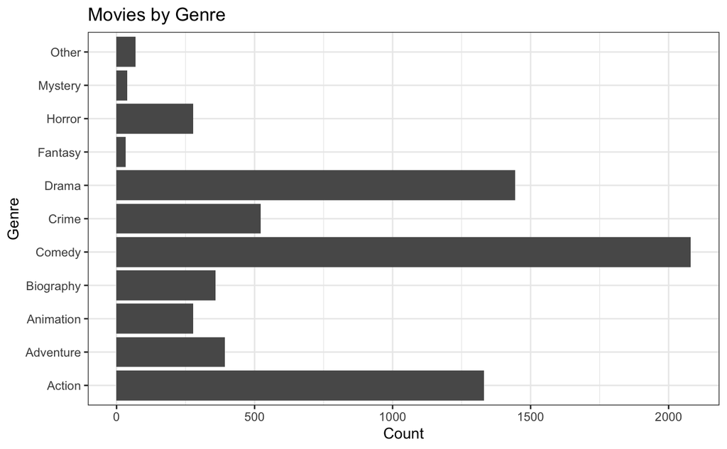

```r
dbplot_bar(movies_tbl, genre) +
  labs(title = "Movies by Genre",
       x = "Genre",
       y = "Count") +
  coord_flip()
```

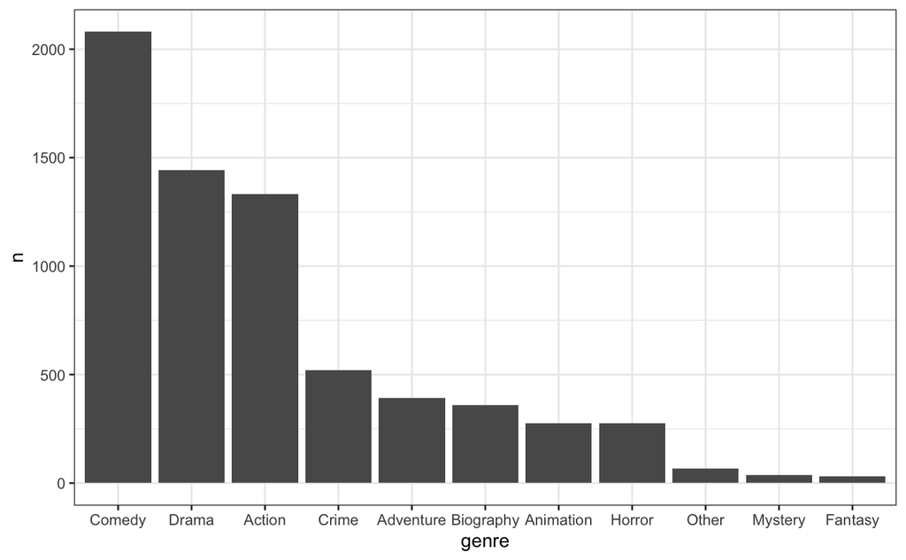

```r
db_compute_count(movies_tbl, genre) %>%
  rename(n = 'n()') %>%
  mutate(genre = fct_reorder(genre, -n, max)) %>%
  ggplot(aes(x = genre, y = n)) +
  geom_col()
```